# pandas_missing_data

## Data Cleaning with Python and Pandas: Detecting Missing Values

Author: John Sullivan

Source: https://towardsdatascience.com/data-cleaning-with-python-and-pandas-detecting-missing-values-3e9c6ebcf78b

### Getting Started

Before you start cleaning a data set, it’s a good idea to just get a general feel for the data. After that, you can put together a plan to clean the data.

I like to start by asking the following questions:

- What are the features?
- What are the expected types (int, float, string, boolean)?
- Is there obvious missing data (values that Pandas can detect)?
- Is there other types of missing data that’s not so obvious (can’t easily detect with Pandas)?

To show you what I mean, let’s start working through the example.

```python
# Importing libraries
import pandas as pd
import numpy as np
from sklearn import linear_model
import matplotlib.pyplot as plt
import seaborn as sns

plt.rcParams["figure.figsize"] = (10,10)
```

```python
# Read csv file into a pandas dataframe
df = pd.read_csv("property_data.csv")
```

```python
# Take a look at the first few rows
df.head(10)
```

|  | PID | ST_NUM | ST_NAME | OWN_OCCUPIED | NUM_BEDROOMS | NUM_BATH | SQ_FT |
| --- | --- | --- | --- | --- | --- | --- | --- |
| 0 | 100001000.0 | 104.0 | PUTNAM | Y | 3 | 1 | 1000 |
| 1 | 100002000.0 | 197.0 | LEXINGTON | N | 3 | 1.5 | -- |
| 2 | 100003000.0 | NaN | LEXINGTON | N | NaN | 1 | 850 |
| 3 | 100004000.0 | 201.0 | BERKELEY | 12 | 1 | NaN | 700 |
| 4 | NaN | 203.0 | BERKELEY | Y | 3 | 2 | 1600 |
| 5 | 100006000.0 | 207.0 | BERKELEY | Y | NaN | 1 | 800 |
| 6 | 100007000.0 | NaN | WASHINGTON | NaN | 2 | HURLEY | 950 |
| 7 | 100008000.0 | 213.0 | TREMONT | Y | 1 | 1 | NaN |
| 8 | 100009000.0 | 215.0 | TREMONT | Y | na | 2 | 1800 |

**What are the dataset features?**

- `ST_NUM` : Street number
- `ST_NAME` : Street name
- `OWN_OCCUPIED` : Is the residence owner occupied
- `NUM_BEDROOMS` : Number of bedrooms
- `NUM_BATH` : Number of bathrooms
- `SQ_FT`: Gross square feet

```python
df.info()
```

```
<class 'pandas.core.frame.DataFrame'>
RangeIndex: 9 entries, 0 to 8
Data columns (total 7 columns):
 #   Column        Non-Null Count  Dtype
---  ------        --------------  -----
 0   PID           8 non-null      float64
 1   ST_NUM        7 non-null      float64
 2   ST_NAME       9 non-null      object
 3   OWN_OCCUPIED  8 non-null      object
 4   NUM_BEDROOMS  7 non-null      object
 5   NUM_BATH      8 non-null      object
 6   SQ_FT         8 non-null      object
dtypes: float64(2), object(5)
memory usage: 632.0+ bytes
```

What are the expected data types?

- `ST_NUM` : float or int… some sort of numeric type
- `ST_NAME` : string
- `OWN_OCCUPIED` : string… Y (“Yes”) or N (“No”)
- `NUM_BEDROOMS` : float or int, a numeric type
- `NUM_BATH` : float, a numeric type
- `SQ_FT`: float or int, a numeric type

### Standard Missing Values

```python
# Looking at the ST_NUM column
print(df['ST_NUM'])
print(df['ST_NUM'].isnull())
```

```
0    104.0
1    197.0
2      NaN
3    201.0
4    203.0
5    207.0
6      NaN
7    213.0
8    215.0
Name: ST_NUM, dtype: float64
0    False
1    False
2     True
3    False
4    False
5    False
6     True
7    False
8    False
Name: ST_NUM, dtype: bool
```

### Non-standard Missing Values

```python
# Looking at the NUM_BEDROOMS column
print(df['NUM_BEDROOMS'])
print(df['NUM_BEDROOMS'].isnull())
```

```
0      3
1      3
2    NaN
3      1
4      3
5    NaN
6      2
7      1
8     na
Name: NUM_BEDROOMS, dtype: object
0    False
1    False
2     True
3    False
4    False
5     True
6    False
7    False
8    False
Name: NUM_BEDROOMS, dtype: bool
```

```python
# Making a list of missing value types
missing_values = ["n/a", "na", "--"]
df = pd.read_csv("property_data.csv", na_values = missing_values)
```

```python
# Looking at the NUM_BEDROOMS column
print(df['NUM_BEDROOMS'])
print(df['NUM_BEDROOMS'].isnull())
```

```
0    3.0
1    3.0
2    NaN
3    1.0
4    3.0
5    NaN
6    2.0
7    1.0
8    NaN
Name: NUM_BEDROOMS, dtype: float64
0    False
1    False
2     True
3    False
4    False
5     True
6    False
7    False
8     True
Name: NUM_BEDROOMS, dtype: bool
```

### Unexpected Missing Values

```python
# Looking at the OWN_OCCUPIED column
print(df['OWN_OCCUPIED'])
print(df['OWN_OCCUPIED'].isnull())
```

```
0      Y
1      N
2      N
3     12
4      Y
5      Y
6    NaN
7      Y
8      Y
Name: OWN_OCCUPIED, dtype: object
0    False
1    False
2    False
3    False
4    False
5    False
6     True
7    False
8    False
Name: OWN_OCCUPIED, dtype: bool
```

This example is a little more complicated so we’ll need to think through a strategy for detecting these types of missing values. There’s a number of different approaches, but here’s the way that I’m going to work through this one.

1. Loop through the OWN_OCCUPIED column
2. Try and turn the entry into an integer
3. If the entry can be changed into an integer, enter a missing value
4. If the number can’t be an integer, we know it’s a string, so keep going

Let’s take a look at the code and then we’ll go through it in detail.

```python
# Detecting numbers in OWN_OCCUPIED column
cnt=0
for row in df['OWN_OCCUPIED']:
    try:
        int(row)
        df.loc[cnt, 'OWN_OCCUPIED']=np.nan
    except ValueError:
        pass
    cnt+=1
```

```python
# coerce NUM_BATH to numeric
df['NUM_BATH'] = pd.to_numeric(df['NUM_BATH'], errors='coerce')
```

```python
df.head(10)
```

|  | PID | ST_NUM | ST_NAME | OWN_OCCUPIED | NUM_BEDROOMS | NUM_BATH | SQ_FT |
| --- | --- | --- | --- | --- | --- | --- | --- |
| 0 | 100001000.0 | 104.0 | PUTNAM | Y | 3.0 | 1.0 | 1000.0 |
| 1 | 100002000.0 | 197.0 | LEXINGTON | N | 3.0 | 1.5 | NaN |
| 2 | 100003000.0 | NaN | LEXINGTON | N | NaN | 1.0 | 850.0 |
| 3 | 100004000.0 | 201.0 | BERKELEY | NaN | 1.0 | NaN | 700.0 |
| 4 | NaN | 203.0 | BERKELEY | Y | 3.0 | 2.0 | 1600.0 |
| 5 | 100006000.0 | 207.0 | BERKELEY | Y | NaN | 1.0 | 800.0 |
| 6 | 100007000.0 | NaN | WASHINGTON | NaN | 2.0 | NaN | 950.0 |
| 7 | 100008000.0 | 213.0 | TREMONT | Y | 1.0 | 1.0 | NaN |
| 8 | 100009000.0 | 215.0 | TREMONT | Y | NaN | 2.0 | 1800.0 |

You’ll notice that I used `try` and except `ValueError`. This is called exception handling, and we use this to handle errors.

If we were to try and change an entry into an integer and it couldn’t be changed, then a `ValueError` would be returned, and the code would stop. To deal with this, we use exception handling to recognize these errors, and keep going. Another important bit of the code is the `.loc` method. This is the preferred Pandas method for modifying entries in place.

### Summarizing Missing Values

```python
# Total missing values for each feature
df.isnull().sum()
```

```
PID             1
ST_NUM          2
ST_NAME         0
OWN_OCCUPIED    2
NUM_BEDROOMS    3
NUM_BATH        2
SQ_FT           2
dtype: int64
```

```python
# Final check: any missing values?
df.isnull().values.any()
```

```
True
```

```python
# Total number of missing values
df.isnull().sum().sum()
```

```
12
```

### Replacing Missing Values

```python
# Replace missing values with a number
df['PID'].fillna(100005000, inplace=True)
df['ST_NUM'].fillna(125, inplace=True)
```

```python
# Location based replacement
df.loc[6,'ST_NUM'] = 151
```

```python
# Replace using median
median = df['NUM_BEDROOMS'].median()
df['NUM_BEDROOMS'].fillna(median, inplace=True)
```

```python
# Replace using mode
df['OWN_OCCUPIED'].fillna(df['OWN_OCCUPIED'].mode()[0], inplace=True)
```

```python
df.head(10)
```

|  | PID | ST_NUM | ST_NAME | OWN_OCCUPIED | NUM_BEDROOMS | NUM_BATH | SQ_FT |
| --- | --- | --- | --- | --- | --- | --- | --- |
| 0 | 100001000.0 | 104.0 | PUTNAM | Y | 3.0 | 1.0 | 1000.0 |
| 1 | 100002000.0 | 197.0 | LEXINGTON | N | 3.0 | 1.5 | NaN |
| 2 | 100003000.0 | 125.0 | LEXINGTON | N | 2.5 | 1.0 | 850.0 |
| 3 | 100004000.0 | 201.0 | BERKELEY | Y | 1.0 | NaN | 700.0 |
| 4 | 100005000.0 | 203.0 | BERKELEY | Y | 3.0 | 2.0 | 1600.0 |
| 5 | 100006000.0 | 207.0 | BERKELEY | Y | 2.5 | 1.0 | 800.0 |
| 6 | 100007000.0 | 151.0 | WASHINGTON | Y | 2.0 | NaN | 950.0 |
| 7 | 100008000.0 | 213.0 | TREMONT | Y | 1.0 | 1.0 | NaN |
| 8 | 100009000.0 | 215.0 | TREMONT | Y | 2.5 | 2.0 | 1800.0 |

### Imputing numeric values

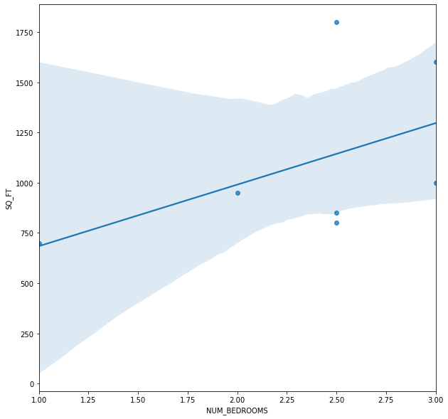

```python
# let's visualize NUM_BEDROOMS and SQ_FT
sns.regplot(x=df['NUM_BEDROOMS'], y=df['SQ_FT'])
```

```python
# correlation between NUM_BEDROOMS adn SQ_FT
df['NUM_BEDROOMS'].corr(df['SQ_FT'])
```

```
0.4969666049661816
```

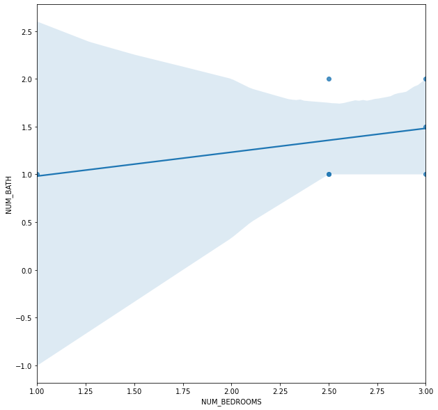

```python
# let's visualize NUM_BEDROOMS and NUM_BATH
sns.regplot(x=df['NUM_BEDROOMS'], y=df['NUM_BATH'])
```

```python
# correlation between NUM_BEDROOMS adn NUM_BATH
df['NUM_BEDROOMS'].corr(df['NUM_BATH'])
```

```
0.37169597083751404
```

```python
# impute NUM_BATH and SQ_FT with a simple regression with x = NUM_BEDROOMS
# Source: https://www.kaggle.com/shashankasubrahmanya/missing-data-imputation-using-regression
missing_columns = ['NUM_BATH', 'SQ_FT']
```

```python
# create _imp columns
for feature in missing_columns:
    df[feature + '_imp'] = df[feature]
```

```python
# replace NAN with 0 on _imp columns
df['NUM_BATH_imp'].fillna(0, inplace=True)
df['SQ_FT_imp'].fillna(0, inplace=True)
```

```python
df.head(10)
```

|  | PID | ST_NUM | ST_NAME | OWN_OCCUPIED | NUM_BEDROOMS | NUM_BATH | SQ_FT | NUM_BATH_imp | SQ_FT_imp |
| --- | --- | --- | --- | --- | --- | --- | --- | --- | --- |
| 0 | 100001000.0 | 104.0 | PUTNAM | Y | 3.0 | 1.0 | 1000.0 | 1.0 | 1000.0 |
| 1 | 100002000.0 | 197.0 | LEXINGTON | N | 3.0 | 1.5 | NaN | 1.5 | 0.0 |
| 2 | 100003000.0 | 125.0 | LEXINGTON | N | 2.5 | 1.0 | 850.0 | 1.0 | 850.0 |
| 3 | 100004000.0 | 201.0 | BERKELEY | Y | 1.0 | NaN | 700.0 | 0.0 | 700.0 |
| 4 | 100005000.0 | 203.0 | BERKELEY | Y | 3.0 | 2.0 | 1600.0 | 2.0 | 1600.0 |
| 5 | 100006000.0 | 207.0 | BERKELEY | Y | 2.5 | 1.0 | 800.0 | 1.0 | 800.0 |
| 6 | 100007000.0 | 151.0 | WASHINGTON | Y | 2.0 | NaN | 950.0 | 0.0 | 950.0 |
| 7 | 100008000.0 | 213.0 | TREMONT | Y | 1.0 | 1.0 | NaN | 1.0 | 0.0 |
| 8 | 100009000.0 | 215.0 | TREMONT | Y | 2.5 | 2.0 | 1800.0 | 2.0 | 1800.0 |

```python
# Create a Linear Regression model to estimate the missing data
model = linear_model.LinearRegression()

X = df.iloc[:, 4].values.reshape(-1, 1)  # values converts it into a numpy array

for feature in missing_columns:
    model.fit(X, y = df[feature + '_imp'])
    df.loc[df[feature].isnull(), feature + '_imp'] = model.predict(X)[df[feature].isnull()]
```

```python
df.head(10)
```

|  | PID | ST_NUM | ST_NAME | OWN_OCCUPIED | NUM_BEDROOMS | NUM_BATH | SQ_FT | NUM_BATH_imp | SQ_FT_imp |
| --- | --- | --- | --- | --- | --- | --- | --- | --- | --- |
| 0 | 100001000.0 | 104.0 | PUTNAM | Y | 3.0 | 1.0 | 1000.0 | 1.000000 | 1000.000000 |
| 1 | 100002000.0 | 197.0 | LEXINGTON | N | 3.0 | 1.5 | NaN | 1.500000 | 1067.857143 |
| 2 | 100003000.0 | 125.0 | LEXINGTON | N | 2.5 | 1.0 | 850.0 | 1.000000 | 850.000000 |
| 3 | 100004000.0 | 201.0 | BERKELEY | Y | 1.0 | NaN | 700.0 | 0.332418 | 700.000000 |
| 4 | 100005000.0 | 203.0 | BERKELEY | Y | 3.0 | 2.0 | 1600.0 | 2.000000 | 1600.000000 |
| 5 | 100006000.0 | 207.0 | BERKELEY | Y | 2.5 | 1.0 | 800.0 | 1.000000 | 800.000000 |
| 6 | 100007000.0 | 151.0 | WASHINGTON | Y | 2.0 | NaN | 950.0 | 0.898352 | 950.000000 |
| 7 | 100008000.0 | 213.0 | TREMONT | Y | 1.0 | 1.0 | NaN | 1.000000 | 479.945055 |
| 8 | 100009000.0 | 215.0 | TREMONT | Y | 2.5 | 2.0 | 1800.0 | 2.000000 | 1800.000000 |

```python
# replace NUM_BATH equal 1 if less than 1
df.loc[df.NUM_BATH_imp < 1, 'NUM_BATH_imp'] = 1
```

```python
df.head(10)
```

|  | PID | ST_NUM | ST_NAME | OWN_OCCUPIED | NUM_BEDROOMS | NUM_BATH | SQ_FT | NUM_BATH_imp | SQ_FT_imp |
| --- | --- | --- | --- | --- | --- | --- | --- | --- | --- |
| 0 | 100001000.0 | 104.0 | PUTNAM | Y | 3.0 | 1.0 | 1000.0 | 1.0 | 1000.000000 |
| 1 | 100002000.0 | 197.0 | LEXINGTON | N | 3.0 | 1.5 | NaN | 1.5 | 1067.857143 |
| 2 | 100003000.0 | 125.0 | LEXINGTON | N | 2.5 | 1.0 | 850.0 | 1.0 | 850.000000 |
| 3 | 100004000.0 | 201.0 | BERKELEY | Y | 1.0 | NaN | 700.0 | 1.0 | 700.000000 |
| 4 | 100005000.0 | 203.0 | BERKELEY | Y | 3.0 | 2.0 | 1600.0 | 2.0 | 1600.000000 |
| 5 | 100006000.0 | 207.0 | BERKELEY | Y | 2.5 | 1.0 | 800.0 | 1.0 | 800.000000 |
| 6 | 100007000.0 | 151.0 | WASHINGTON | Y | 2.0 | NaN | 950.0 | 1.0 | 950.000000 |
| 7 | 100008000.0 | 213.0 | TREMONT | Y | 1.0 | 1.0 | NaN | 1.0 | 479.945055 |
| 8 | 100009000.0 | 215.0 | TREMONT | Y | 2.5 | 2.0 | 1800.0 | 2.0 | 1800.000000 |

```python
# replace NUM_BATH and SQ_FT with _imp columns values
df_imp = df.copy()
df_imp['NUM_BATH'] = df_imp['NUM_BATH_imp']
df_imp['SQ_FT'] = df_imp['SQ_FT_imp']
```

```python
df_imp.drop(['NUM_BATH_imp', 'SQ_FT_imp'], axis=1, inplace=True)
```

```python
df_imp.head(10)
```

|  | PID | ST_NUM | ST_NAME | OWN_OCCUPIED | NUM_BEDROOMS | NUM_BATH | SQ_FT |
| --- | --- | --- | --- | --- | --- | --- | --- |
| 0 | 100001000.0 | 104.0 | PUTNAM | Y | 3.0 | 1.0 | 1000.000000 |
| 1 | 100002000.0 | 197.0 | LEXINGTON | N | 3.0 | 1.5 | 1067.857143 |
| 2 | 100003000.0 | 125.0 | LEXINGTON | N | 2.5 | 1.0 | 850.000000 |
| 3 | 100004000.0 | 201.0 | BERKELEY | Y | 1.0 | 1.0 | 700.000000 |
| 4 | 100005000.0 | 203.0 | BERKELEY | Y | 3.0 | 2.0 | 1600.000000 |
| 5 | 100006000.0 | 207.0 | BERKELEY | Y | 2.5 | 1.0 | 800.000000 |
| 6 | 100007000.0 | 151.0 | WASHINGTON | Y | 2.0 | 1.0 | 950.000000 |
| 7 | 100008000.0 | 213.0 | TREMONT | Y | 1.0 | 1.0 | 479.945055 |
| 8 | 100009000.0 | 215.0 | TREMONT | Y | 2.5 | 2.0 | 1800.000000 |

```python
# for imputing numeric values (NUM_BATH, SQ_FT) we need first to label encode ST_NAME, OWN_OCCUPIED
# from sklearn import preprocessing

# le = preprocessing.LabelEncoder()
# df['ST_NAME'] = le.fit_transform(df['ST_NAME'])
# df['OWN_OCCUPIED'] = le.fit_transform(df['OWN_OCCUPIED'])
```

```python
# replace numeric columns with mising value with sklearn.IterativeImputer
# from sklearn.experimental import enable_iterative_imputer
# from sklearn.impute import IterativeImputer
# imp = IterativeImputer(max_iter=100, verbose=0)
# imp.fit(df)
# imputed_df = imp.transform(df)
# imputed_df = pd.DataFrame(imputed_df, columns=df.columns)
```

```python
# imputed_df.head(10)
```